# Introducing europepmc, an R interface to Europe PMC RESTful API

Najko Jahn

12 July 2016

[Europe PMC](http://europepmc.org/) covers life science literature and gives access to open access full texts. Europe PMC ingests all PubMed content and extends its index with other sources, including Agricola, a bibliographic database of citations to the agricultural literature, or Biological Patents.

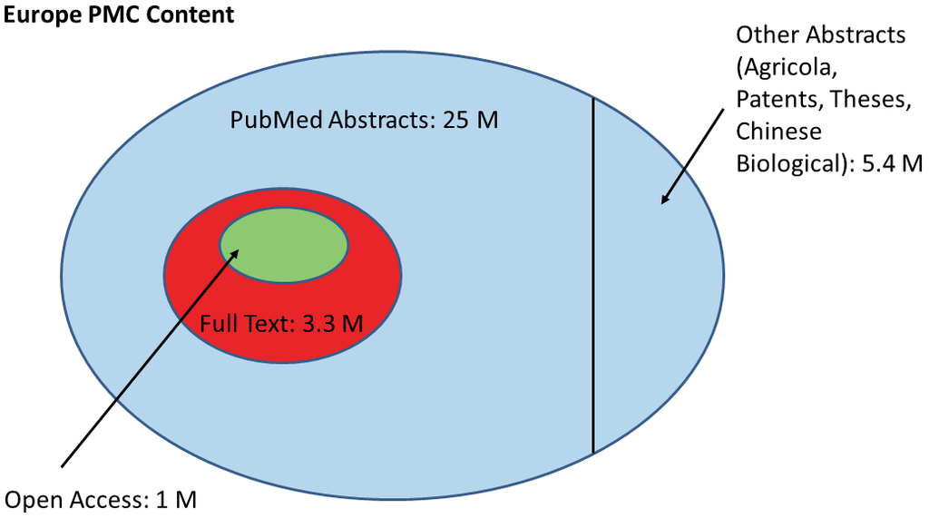

Index coverage

For more background, see:

https://europepmc.org/About

Europe PMC: a full-text literature database for the life sciences and platform for innovation. (2014). Nucleic Acids Research, 43(D1), D1042–D1048. http://doi.org/10.1093/nar/gku1061

## Installation

The latest development version can be installed using devtools package:

```r
require(devtools)
install_github("ropensci/europepmc")
```

## Search Europe PMC

The search covers both metadata (e.g. abstracts or title) and full texts. To build your query, please refer to the comprehensive guidance on how to search Europe PMC: http://europepmc.org/help. Simply provide your query in the Europe PMC search syntax to `epmc_search()`.

The search function helps to get a general overview about additional information types that are offered by Europe PMC and which can be retrieved through other `europepmc`-functions. Columns inform whether open access full texts (`isOpenAccess`), cross-links to other EBI databases (`hasDbCrossReferences`), text-mined terms (`hasTextMinedTerms`) or references (`hasReferences`) are available.

By default, `epmc_search` returns 25 records. To adjust the limit, simply use the `limit` parameter.

Either list of publication ids (`id_list = TRUE`) or key metadata information (`id_list = FALSE`, default option) are returned.

For instance, search for abstracts and full texts that mention `Gabi-Kat`:

```r
library(europepmc)
my_data <- epmc_search(query = 'Gabi-Kat')
# first six records
head(my_data)
```

```
#>         id source     pmid      pmcid                          doi
#> 1 27117628    MED 27117628 PMC4846993            10.1038/srep24971
#> 2 26842807    MED 26842807 PMC4740857            10.1038/srep20309
#> 3 26930070    MED 26930070 PMC4773003 10.1371/journal.pone.0150254
#> 4 26957563    MED 26957563 PMC4861014           10.1093/jxb/erw096
#> 5 27216227    MED 27216227 PMC4890181          10.1038/ncomms11654
#> 6 27064270    MED 27064270 PMC4814454      10.3389/fpls.2016.00405
#>                                                                                                                                                                                                                  title
#> 1                                                                                                                         Cancer-specific binary expression system activated in mice by bacteriophage HK022 Integrase.
#> 2                                                                                  Precocious leaf senescence by functional loss of PROTEIN S-ACYL TRANSFERASE14 involves the NPR1-dependent salicylic acid signaling.
#> 3 The Arabidopsis Domain of Unknown Function 1218 (DUF1218) Containing Proteins, MODIFYING WALL LIGNIN-1 and 2 (At1g31720/MWL-1 and At4g19370/MWL-2) Function Redundantly to Alter Secondary Cell Wall Lignin Content.
#> 4                                                                                                                                                                  SLTAB2 is the paramutated SULFUREA locus in tomato.
#> 5                                                                                                                                            A voltage-dependent chloride channel fine-tunes photosynthesis in plants.
#> 6                                                                                          Photosystem II Repair and Plant Immunity: Lessons Learned from Arabidopsis Mutant Lacking the THYLAKOID LUMEN PROTEIN 18.3.
#>                                                                                                                                    authorString
```

[output cut: 41 more lines]

Get PLOS Genetics (ISSN:1553-7404) articles that cross-reference EMBL:

```r
my_data <- epmc_search(query = 'ISSN:1553-7404 HAS_EMBL:y')
head(my_data)
```

```
#>         id source     pmid      pmcid                          doi
#> 1 27149082    MED 27149082 PMC4858218 10.1371/journal.pgen.1006030
#> 2 27203426    MED 27203426 PMC4874600 10.1371/journal.pgen.1006063
#> 3 26982327    MED 26982327 PMC4794157 10.1371/journal.pgen.1005920
#> 4 27120580    MED 27120580 PMC4847869 10.1371/journal.pgen.1005987
#> 5 27327578    MED 27327578 PMC4915694 10.1371/journal.pgen.1006110
#> 6 27082250    MED 27082250 PMC4833346 10.1371/journal.pgen.1005954
#>                                                                                                                                                                                                    title
#> 1 Germline Defects Caused by Smed-boule RNA-Interference Reveal That Egg Capsule Deposition Occurs Independently of Fertilization, Ovulation, Mating, or the Presence of Gametes in Planarian Flatworms.
#> 2                                                                                                Antimicrobial Functions of Lactoferrin Promote Genetic Conflicts in Ancient Primates and Modern Humans.
#> 3                                                                                                            Hybrid Dysgenesis in Drosophila simulans Associated with a Rapid Invasion of the P-Element.
#> 4                                                 An Indel Polymorphism in the MtnA 3' Untranslated Region Is Associated with Gene Expression Variation and Local Adaptation in Drosophila melanogaster.
#> 5                                                                                                                      Genetic Dissection of Sexual Reproduction in a Primary Homothallic Basidiomycete.
#> 6                                                                                        Chromosomal-Level Assembly of the Asian Seabass Genome Using Long Sequence Reads and Multi-layered Scaffolding.
#>                                                                                                                                                                                                                                                                                                          …
```

[output cut: 41 more lines]

### Get results number

Count hits before with `epmc_hits` to define limit. For example, get list of ids that represent articles referencing DataCite DOIs:

```r
query <- "ACCESSION_TYPE:doi"
epmc_hits(query)
```

```
#> [1] 5402
```

```r
# set limit to 10 records
my_data <- epmc_search(query = "ACCESSION_TYPE:doi", limit = 10,
                       id_list = TRUE)
head(my_data)
```

```
#>         id source     pmid      pmcid
#> 1 27019208    MED 27019208 PMC4809487
#> 2 26955653    MED 26955653 PMC4761700
#> 3 27064844    MED 27064844 PMC4814564
#> 4 27143036    MED 27143036 PMC4855483
#> 5 26977150    MED 26977150 PMC4762996
#> 6 26978783    MED 26978783 PMC4792385
```

```r
attr(my_data, "hit_count")
```

```
#> [1] 5402
```

### Search with ORCID

Use [ORCID](http://orcid.org/) to search for personal publications:

```r
my_data <- epmc_search(query = 'AUTHORID:"0000-0002-7635-3473"')
attr(my_data, "hit_count")
```

```
#> [1] 127
```

### Include MeSH and UniProt synonyms

You may also want to include synonyms when searching Europe PMC. If `synonym = TRUE` MeSH and UniProt synonyms are searched as well.

```r
my_data <- epmc_search("aspirin", synonym = TRUE)
attr(my_data, "hit_count")
```

```
#> [1] 112983
```

```r
my_data <- epmc_search("aspirin", synonym = FALSE)
attr(my_data, "hit_count")
```

```
#> [1] 105706
```

## Get article details

In addition to key metadata, `epmc_details` also returns full metadata providing more comprehensive information on the article-level. By default, PubMed / Medline index is searched.

```r
epmc_details(ext_id = "24270414")
```

```
#> $basic
#>         id source     pmid      pmcid              doi
#> 1 24270414    MED 24270414 PMC3859427 10.1172/jci73168
#>                                     title                 authorString
#> 1 ADCK4 "reenergizes" nephrotic syndrome. Malaga-Dieguez L, Susztak K.
#>    pageInfo
#> 1 4996-4999
#>                                                                                                                                                                                                                                                                                                          …
#> 1 Steroid-resistant nephrotic syndrome has a poor prognosis and often leads to end-stage renal disease development. In this issue of the JCI, Ashraf and colleagues used exome sequencing to identify mutations in the aarF domain containing kinase 4 (ADCK4) gene that cause steroid-resistant nephroti…
#>   language         pubModel isOpenAccess inEPMC inPMC hasPDF hasBook
#> 1      eng Print-Electronic            N      Y     Y      Y       N
#>   hasSuppl citedByCount hasReferences hasTextMinedTerms
#> 1        N            1             Y                 Y
#>   hasDbCrossReferences hasLabsLinks epmcAuthMan hasTMAccessionNumbers
#> 1                    N            Y           N                     N
#>   dateOfCompletion dateOfCreation dateOfRevision electronicPublicationDate
#> 1       2014-02-04     2013-12-02     2015-07-10                2013-11-25
#>   firstPublicationDate luceneScore
#> 1           2013-11-25         NaN
#>
#> $author_details
#>           fullName firstName       lastName initials
#> 1 Malaga-Dieguez L     Laura Malaga-Dieguez        L
#> 2        Susztak K   Katalin        Susztak        K
#>
#> $journal_info
#>   issue volume journalIssueId dateOfPublication monthOfPublication
#> 1    12    123        2099360          2013 Dec                 12
#>   yearOfPublication printPublicationDate
#> 1              2013           2013-12-01
#>                           journal.title journal.medlineAbbreviation
#> 1 The Journal of clinical investigation               J Clin Invest
#>   journal.essn journal.issn journal.isoabbreviation journal.nlmid
#> 1    1558-8238    0021-9738        J. Clin. Invest.       7802877
#>
#> $ftx
#>            availability availabilityCode documentStyle          site
#> 1                  Free                F           pdf    Europe_PMC
#> 2                  Free                F          html    Europe_PMC
#> 3                  Free                F           pdf PubMedCentral
```

[output cut: 18 more lines]

```
#> 1             N            Animals
#> 2             N             Humans
#> 3             N Nephrotic Syndrome
#> 4             N         Ubiquinone
#> 5             N    Protein Kinases
#>
#> $comments
#>         id source                               reference       type
#> 1 24270420    MED J Clin Invest. 2013 Dec;123(12):5179-89 Comment on
#>   orderIn
#> 1      19
#>
#> $grants
#>       grantId        agency acronym orderIn
#> 1 R01DK076077 NIDDK NIH HHS      DK       0
```

Show author details including ORCID:

```r
my_data <- epmc_details(ext_id = "14756321")
my_data$author_details
```

```
#>      fullName firstName  lastName initials authorId.type
#> 1    Rosso MG   Mario G     Rosso       MG          <NA>
#> 2        Li Y      Yong        Li        Y          <NA>
#> 3  Strizhov N   Nicolai  Strizhov        N          <NA>
#> 4     Reiss B     Bernd     Reiss        B         ORCID
#> 5    Dekker K      Koen    Dekker        K          <NA>
#> 6 Weisshaar B     Bernd Weisshaar        B         ORCID
#>        authorId.value
#> 1                <NA>
#> 2                <NA>
#> 3                <NA>
#> 4 0000-0002-2521-4000
#> 5                <NA>
#> 6 0000-0002-7635-3473
```

## Get citation counts and citing publications

Citing publications from the Europe PMC index can be retrieved like this:

```r
my_cites <- epmc_citations("9338777")
head(my_cites)
```

```
#>         id source
#> 1  9525633    MED
#> 2  9811736    MED
#> 3  9728986    MED
#> 4  9728985    MED
#> 5  9728987    MED
#> 6 10590090    MED
#>                                                                              citationType
#> 1                                                                         Journal Article
#> 2                                       Journal Article; Research Support, Non-U.S. Gov't
#> 3 Journal Article; Research Support, Non-U.S. Gov't; Research Support, U.S. Gov't, P.H.S.
#> 4                                       Journal Article; Research Support, Non-U.S. Gov't
#> 5                         Case Reports; Journal Article; Research Support, Non-U.S. Gov't
#> 6                                       Journal Article; Research Support, Non-U.S. Gov't
#>                                                                                                                  title
```

[output cut: 20 more lines]

```r
attr(my_cites, "hit_count")
```

```
#> [1] 192
```

Please note, that citation counts are often smaller than those held by toll- access services such as Web of Science or Scopus because the number of reference sections indexed for Europe PMC considerably differs due to the lack of full text accessibility.

## Get reference section

Europe PMC indexes more than 5 million reference sections.

```r
epmc_refs("PMC3166943", data_src = "pmc")
```

```
#>          id source    citationType
#> 1  10802651    MED JOURNAL ARTICLE
#> 2      <NA>   <NA>            <NA>
#> 3  18077472    MED JOURNAL ARTICLE
#> 4  15642104    MED JOURNAL ARTICLE
#> 5  18460184    MED JOURNAL ARTICLE
#> 6  17989687    MED JOURNAL ARTICLE
#> 7  20848809    MED JOURNAL ARTICLE
#> 8  20139945    MED JOURNAL ARTICLE
#> 9      <NA>   <NA>            <NA>
#> 10 17267433    MED JOURNAL ARTICLE
#> 11 15199967    MED JOURNAL ARTICLE
#> 12 14681407    MED JOURNAL ARTICLE
#> 13 16756499    MED JOURNAL ARTICLE
#> 14 16959967    MED JOURNAL ARTICLE
```

[output cut: 99 more lines]

Tip: add `has_reflist:y` to your search string in `epmc_search` to make sure you only get publications whose reference sections are accessible through Europe PMC.

## Retrieve links to other EBI databases

Cross-links to EBI databases are either manually curated (ENA, InterPro, PDB, IntAct, ChEMBL, ChEBI and ArrayExpress) or automatically gathered through text-mining (European Nucleotide Archive, UniProt, PDB, OMIM, RefSNP, RefSeq, Pfam, InterPro, Ensembl, ArrayExpress and data DOIs).

Before retrieving the links, please check availability and sources first:

```r
epmc_db_count("12368864")
```

```
#>     dbName count
#> 1     EMBL    10
#> 2 INTERPRO     1
#> 3  UNIPROT  5588
```

Add `has_xrefs:y` or to your search string in `epmc_search` to make sure you only get publications with cross-references to EBI databases.

Select database and get links:

```r
epmc_db("12368864", db = "embl")
```

```
#>       info1                                                       info2
#> 1  AE014187 Plasmodium falciparum 3D7 chromosome 14, complete sequence.
#> 2  AE014186 Plasmodium falciparum 3D7 chromosome 11, complete sequence.
#> 3  LN999943  Plasmodium falciparum 3D7 chromosome 2, complete sequence.
#> 4  AE001362  Plasmodium falciparum 3D7 chromosome 2, complete sequence.
#> 5  LN999947 Plasmodium falciparum 3D7 chromosome 12, complete sequence.
#> 6  AE014185 Plasmodium falciparum 3D7 chromosome 10, complete sequence.
#> 7  LN999944 Plasmodium falciparum 3D7 chromosome 10, complete sequence.
#> 8  LN999945 Plasmodium falciparum 3D7 chromosome 11, complete sequence.
#> 9  LN999946 Plasmodium falciparum 3D7 chromosome 14, complete sequence.
#> 10 AE014188 Plasmodium falciparum 3D7 chromosome 12, complete sequence.
#>      info3 info4
#> 1  3291871    10
#> 2  2038337    10
#> 3   947102    10
#> 4   947102    10
#> 5  2271494    10
#> 6  1687655    10
#> 7  1687656    10
#> 8  2038340    10
#> 9  3291936    10
#> 10 2271478    10
```

## Get text-mined terms

Text-mined terms that can be accessed via Europe PMC are mapped against controlled vocabularies such as [Gene Ontology](http://www.ebi.ac.uk/QuickGO/).

Before retrieving these terms, please check availability and vocabularies first:

```r
epmc_tm_count("25249410")
```

```
#>           name count
#> 1    accession     1
#> 2     chemical    25
#> 3      disease     1
#> 4          efo    28
#> 5 gene_protein    51
#> 6      go_term    17
#> 7     organism    27
```

Select vocabulary to retrieve the terms:

```r
epmc_tm("25249410", semantic_type = "GO_TERM")
```

```
#>                             term count              altName dbName    dbId
#> 1                     chromosome    25          chromosomes     GO 0005694
#> 2                   biosynthesis    16 formation, synthesis     GO 0009058
#> 3                        binding     9                          GO 0005488
#> 4                          cells     5                 cell     GO 0005623
#> 5                         growth     4               Growth     GO 0040007
#> 6         flavonoid biosynthesis     3                          GO 0009813
#> 7                gene expression     2                          GO 0010467
#> 8           secondary metabolism     2                          GO 0019748
#> 9                     metabolism     2                          GO 0008152
#> 10             defense responses     1                          GO 0006952
#> 11            cell cycle control     1                          GO 1901987
#> 12 regulation of gene expression     1                          GO 0010468
#> 13    glucosinolate biosynthesis     1                          GO 0019761
#> 14              cell development     1                          GO 0048468
#> 15                    root hairs     1                          GO 0035618
#> 16      anthocyanin biosynthesis     1                          GO 0009718
#> 17             enzyme activities     1                          GO 0003824
```

## Links to external sources

With the External Link services, Europe PMC allows third parties to publish links from Europe PMC to other webpages. Current External Link providers, whose id can be found through Europe PMC’s Advanced Search interface, include Wikipedia, Dryad Digital Repository or the institutional repo of Bielefeld University. For more information, see http://europepmc.org/labslink.

Check availability and number of links:

```r
epmc_lablinks_count("PMC3986813", data_src = "pmc")
```

```
#>       providerName linksCount
#> 1 EBI Train Online          1
#> 2        Wikipedia          1
#> 3          Publons          1
#> 4        Altmetric          1
```

Get links to PANGEA (`lab_id = "1342"`)

```r
epmc_lablinks("24023770", lab_id = "1342")
```

```
#>                                                                                                                                                                                                title
#> 1  Related to: Schewe, I (2010). Biochemical investigation of multicorer sediment profile PS74/106-3. Alfred Wegener Institute, Helmholtz Center for Polar and Marine Research, Bremerhaven, PANGAEA
#> 2  Related to: Schewe, I (2010). Biochemical investigation of multicorer sediment profile PS74/107-2. Alfred Wegener Institute, Helmholtz Center for Polar and Marine Research, Bremerhaven, PANGAEA
#> 3  Related to: Schewe, I (2010). Biochemical investigation of multicorer sediment profile PS74/108-2. Alfred Wegener Institute, Helmholtz Center for Polar and Marine Research, Bremerhaven, PANGAEA
#> 4  Related to: Schewe, I (2010). Biochemical investigation of multicorer sediment profile PS74/109-2. Alfred Wegener Institute, Helmholtz Center for Polar and Marine Research, Bremerhaven, PANGAEA
#> 5  Related to: Schewe, I (2010). Biochemical investigation of multicorer sediment profile PS74/113-2. Alfred Wegener Institute, Helmholtz Center for Polar and Marine Research, Bremerhaven, PANGAEA
#> 6  Related to: Schewe, I (2010). Biochemical investigation of multicorer sediment profile PS74/116-2. Alfred Wegener Institute, Helmholtz Center for Polar and Marine Research, Bremerhaven, PANGAEA
#> 7  Related to: Schewe, I (2010). Biochemical investigation of multicorer sediment profile PS74/118-2. Alfred Wegener Institute, Helmholtz Center for Polar and Marine Research, Bremerhaven, PANGAEA
#> 8  Related to: Schewe, I (2010). Biochemical investigation of multicorer sediment profile PS74/119-2. Alfred Wegener Institute, Helmholtz Center for Polar and Marine Research, Bremerhaven, PANGAEA
#> 9  Related to: Schewe, I (2010). Biochemical investigation of multicorer sediment profile PS74/120-2. Alfred Wegener Institute, Helmholtz Center for Polar and Marine Research, Bremerhaven, PANGAEA
#> 10 Related to: Schewe, I (2010). Biochemical investigation of multicorer sediment profile PS74/121-1. Alfred Wegener Institute, Helmholtz Center for Polar and Marine Research, Bremerhaven, PANGAEA
#> 11 Related to: Schewe, I (2010). Biochemical investigation of multicorer sediment profile PS74/127-2. Alfred Wegener Institute, Helmholtz Center for Polar and Marine Research, Bremerhaven, PANGAEA
#> 12 Related to: Schewe, I (2010). Biochemical investigation of multicorer sediment profile PS74/128-2. Alfred Wegener Institute, Helmholtz Center for Polar and Marine Research, Bremerhaven, PANGAEA
#> 13 Related to: Schewe, I (2010). Biochemical investigation of multicorer sediment profile PS74/129-3. Alfred Wegener Institute, Helmholtz Center for Polar and Marine Research, Bremerhaven, PANGAEA
#>                                         url lab_id lab_name
```

[output cut: 27 more lines]

## Full text access

Full texts are in XML format and are only provided for the Open Access subset of Europe PMC. They can be retrieved by the PMCID.

```r
epmc_ftxt("PMC3257301")
```

```
#> {xml_document}
#> <article article-type="research-article" xmlns:xlink="http://www.w3.org/1999/xlink" xmlns:mml="http://www.w3.org/1998/Math/MathML">
#> [1] <front>\n  <journal-meta>\n    <journal-id journal-id-type="nlm-ta"> ...
#> [2] <body>\n  <sec id="s1">\n    <title>Introduction</title>\n    <p>Atm ...
#> [3] <back>\n  <ack>\n    <p>We would like to thank Dr. C. Gourlay and Dr ...
```

Books, fetched through the PMID or the ‘NBK’ book number, can also be loaded as XML into R for further text-mining activities.

```r
epmc_ftxt_book("NBK32884")
```

```
#> {xml_document}
#> <book-part book-part-type="toc" id="toc" indexed="true" lang="EN" type="simple" xmlns:xlink="http://www.w3.org/1999/xlink" xmlns:mml="http://www.w3.org/1998/Math/MathML">
#> [1] <book-meta>\n  <?showBookmeta?>\n  <book-id pub-id-type="pmcid">erta ...
#> [2] <book-part-meta>\n  <title-group>\n    <title>Table of Contents</tit ...
#> [3] <body>\n  <list list-type="simple">\n    <list-item>\n      <?toc-ta ...
```

Please check full-text availability before.

## Other ways to access Europe PubMed Central

### Other APIs

- Data dumps: https://europepmc.org/FtpSite
- OAI service: https://europepmc.org/OaiService
- SOAP web service: https://europepmc.org/SoapWebServices
- Grants RESTful (Grist) API: https://europepmc.org/GristAPI

### Other R clients

- use rOpenSci’s `oai` to get metadata and full text via Europe PMC’s OAI interface: https://github.com/ropensci/oai
- use rOpenSci’s `rentrez` to interact with [NCBI databases](http://www.ncbi.nlm.nih.gov/) such as [PubMed](http://www.ncbi.nlm.nih.gov/pubmed): https://github.com/ropensci/rentrez
- rOpenSci’s `fulltext` package gives access to supplementary material of open access life-science publications in Europe PMC: https://github.com/ropensci/fulltext